# An Introduction to ggplot2

Bret Larget

Professor Jessi Cisewski Kehe contributed to these lecture notes.

## Overview

- These notes introduce the **ggplot2** package for making plots
- We use data from the Lake Mendota freeze/thaw data set to introduce several types of plots
- Read the [chapter on Lake Mendota](https://bookdown.org/bret_larget/stat-240-case-studies/madison-lakes.html) from the Course Notes and Case Studies for background.
- The R Markdown file for this case study contains all of the code needed to replicate the analysis from lecture.
- However, lecture will skip quickly over the blocks of code that are not directly doing visualization.

### Preliminaries

- For you to be able to run the code in this file, you need to put files in proper locations and set the working directory.
- Let `COURSE` represent your course directory.
1. If it does not yet exist, create the folder `COURSE/lecture`.
2. Create the sub-folder `COURSE/lecture/unit2`
3. Download the file `03-lake-mendota.Rmd` into the `unit2` sub-folder.
4. Download the file `lake-mendota-winters-2021.csv` into the `COURSE/data` folder.

## Read the data

- The following R chunk has one line of code that will read in the data set.
- Along with the code I added many comments to explain what is happening.
- Each code chunk begins with three consecutive back ticks at the start of a line.
- The left brace `{` followed by the letter `r` means that the code should be interpreted as r code.
- The name `read-data` is the name of the chunk.
- Naming chunks is helpful when trying to find errors.
- Other knitr options could be set before the right brace `}`, but are not in this example.
- **Note that each R chunk in a file requires a unique name.**
- We will examine `read_csv()` and other functions to read in data later in the semester.

```r
## `mendota` is a new object.
## The `=` assigns the loaded data set to the object name `mendota`.
## You will often see `<-' instead as the assignment operator.
##   I use `=` almost all the time, but `<-` is more common.
## read_csv() is a function in the tidyverse for reading in .csv files.
## There is a base R function named read.csv(). Use read_csv() instead.
## If you use read.csv(), character variables get changed to factors
##   and variable names might get changed.
## The argument to read_csv() is a path to the file with the data
## The '..' means go up a directory
## Use a '/' after a directory
##   Windows uses backslashes, but slashes work in R for any computer system.
##   We want to write code that is reproducible on any computer, so stick with '/'.
## The result of the code below is to create a data frame named mendota
##   by reading in the data in the file.
### COURSE/data contains the data file
### COURSE/lecture/unit2 is your working directory
mendota = read_csv("lake-mendota-winters-2021.csv")
```

### str( ) and spec( )

- The R command `str()` is useful to check the structure of a data set (or other R objects).
- This code displays the structure of the data set.
- The command `spec()` is part of the tidyverse and displays how each variable is specified after reading in.
- **Note: once you have modified a data set, `spec()` may no longer work.**

```r
spec(mendota)
str(mendota)
```

```
## spec_tbl_df [166 × 7] (S3: spec_tbl_df/tbl_df/tbl/data.frame)
##  $ winter      : chr [1:166] "1855-56" "1856-57" "1857-58" "1858-59" ...
##  $ year1       : num [1:166] 1855 1856 1857 1858 1859 ...
##  $ intervals   : num [1:166] 1 1 1 1 1 1 1 1 1 1 ...
##  $ duration    : num [1:166] 118 151 121 96 110 117 132 104 125 118 ...
##  $ first_freeze: Date[1:166], format: "1855-12-18" "1856-12-06" ...
##  $ last_thaw   : Date[1:166], format: "1856-04-14" "1857-05-06" ...
##  $ decade      : num [1:166] 1850 1850 1850 1850 1850 1860 1860 1860 1860 1860 ...
##  - attr(*, "spec")=
##   .. cols(
##   ..   winter = col_character(),
##   ..   year1 = col_double(),
##   ..   intervals = col_double(),
##   ..   duration = col_double(),
##   ..   first_freeze = col_date(format = ""),
##   ..   last_thaw = col_date(format = ""),
##   ..   decade = col_double()
##   .. )
##  - attr(*, "problems")=<externalptr>
```

## ggplot2

- The **tidyverse** package **ggplot2** is based on a *grammar of graphics* (what the **gg** in **ggplot2** stands for).
- Graphs are based on the following general principles:
  - there is a *mapping* between variables in a data set and various *aesthetics* of the plot
  - *geometries* determine how various aesthetics are represented in the plot
  - a complicated plot may be built by adding several *layers* to the plot
  - additional commands affect other aspects of the plot, such as scales, axes and their annotation, and so on
- The code in the **ggplot2** is a language which implements the grammar of graphics.
- The advantages of having a language for graphs include:
  - *Flexibility*: — the user has a rich language to create a variety of plots which may be customized in countless ways
  - *Reproducibility*: — Code to create graphs may be reused.
  - *Scalability*: — Code for a single graph may be used with iteration to create many graphs

## Plots

- We will first examine a number of plots for visualizing a single quantitative variable.
- Then, we will look at scatter plots to examine relationships between two quantitative variables.
- Additional variables may be shown on a scatter plot via color, shape, size, and other aesthetics, or by breaking a plot into multiple sub-plots by the groups in a categorical variable.

### One-variable Plots

- The variable *duration* is the number of days that Lake Mendota was frozen each winter.
- (We will use the term *frozen* here to mean that the lake surface is at least 50% covered by ice, or *closed*, as described in *CNCS*.)
- This variable can be displayed with many different types of graphs.
- Every plot we make using the **ggplot2** package starts with the function `ggplot()` which takes the name of a data frame as its first argument.
- Then, new layers can be added to the plot.
- This almost always includes at least one geometric element, a function that begins with `geom_` followed by a descriptive name.
- Most plots will include multiple layers to add labels, modify previous layers, add more features to the plot, and so on.
- Note that the `+` sign must be at the end of each line, not the beginning of the line.
- (If not, R thinks you were done adding layers the first time there is not an `+` at the end.)

#### Histogram

- We can use **ggplot2** to make a basic histogram as follows.
- Note that the aesthetics mapping set with `aes()` is an argument in the `geom_*()` function.
- Another possibility is to call it in `ggplot()`.
  - Any aesthetics set in `ggplot2()` carry over to all subsequent layers.
  - Aesthetics set elsewhere only apply to that specific layer.

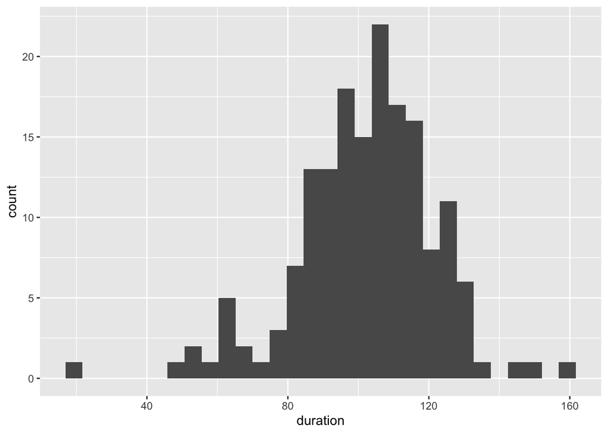

```r
ggplot(mendota) +
  geom_histogram(aes(x=duration))
```

- This histogram changes:
  - the labels with `ggtitle()`, `xlab()`, and `ylab()`
  - the widths of the bars with the `binwidth` argument
  - the boundaries where the bars are set with the `boundary` argument
  - the color of the bar interiors with the `fill` argument
  - the color of the bar outlines with the `color` argument

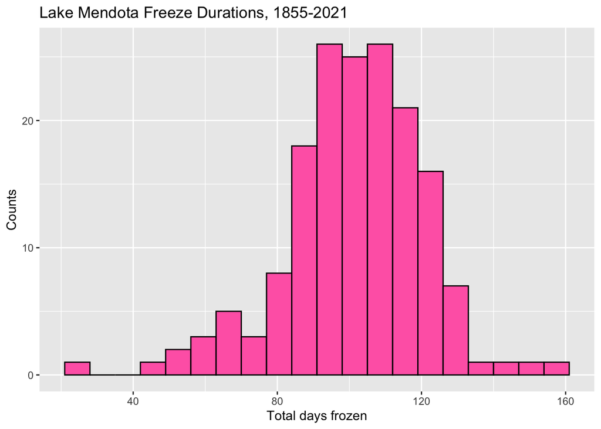

```r
ggplot(mendota) +
  geom_histogram(aes(x=duration),
                 fill="hotpink",
                 color="black",
                 binwidth=7,
                 boundary=0) +
  xlab("Total days frozen") +
  ylab("Counts") +
  ggtitle("Lake Mendota Freeze Durations, 1855-2021")
```

#### Density Plot

A density plot can be thought of as a smoothed histogram.  
We can display a density plot using `geom_density().`

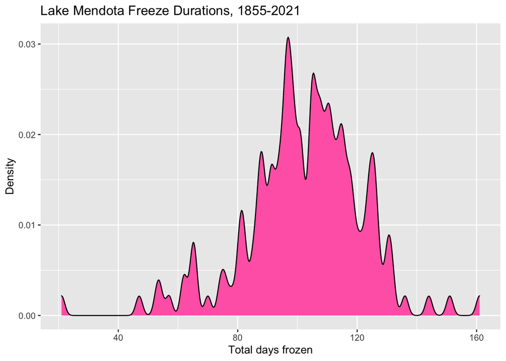

```r
ggplot(mendota) +
  geom_density(aes(x=duration),
               fill="hotpink",
               color="black",
               adjust = 1/5) +
  xlab("Total days frozen") +
  ylab("Density") +
  ggtitle("Lake Mendota Freeze Durations, 1855-2021")
```

#### Boxplot

- A boxplot requires a categorical variable for the x argument and a quantitative variable for the y argument.
- Each box outlines the middle 50% of the observations in the corresponding category:
  - the bottom of the box (i.e., the lower hinge) gives the 25th percentile (the first quartile, Q1)
  - the middle bar give the median (the 50th percentile)
  - the top of the box (i.e., the upper hinge) gives the 75th percentile (the third quartile, Q3)
- The lower vertical line (i.e., the lower whisker) reaches down to the minimum value of the observations, but will not drop below Q1 - 1.5 x IQR, where IQR = Q3 - Q1 is the inter-quartile range.
- Similarly, the higher vertical line (i.e., the upper whisker) reaches up to the maximum value of the observations, but will not go above Q3 + 1.5 x IQR.
- Any points plotted below or above the vertical lines indicate observations that are below or above the noted ranges. These points may be considered outliers.

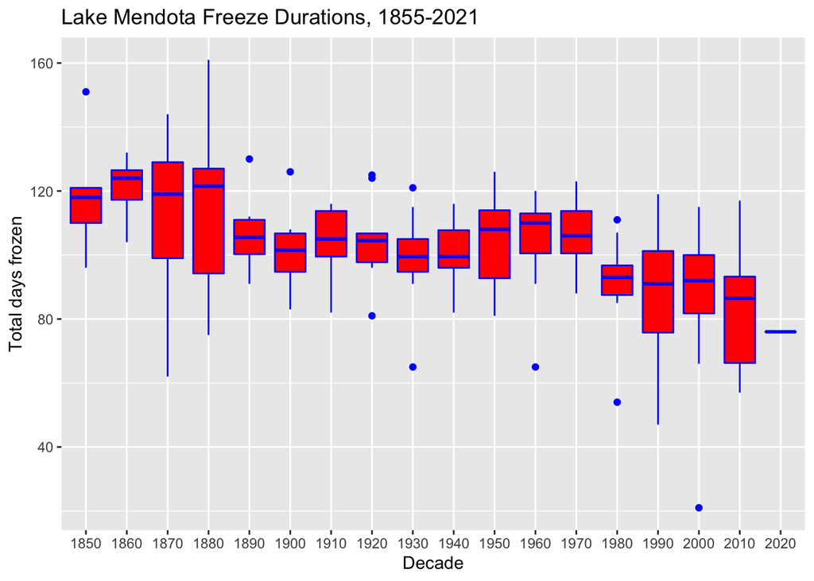

```r
ggplot(mendota) +
  geom_boxplot(aes(x=as.character(decade), y=duration),
               fill="red",
               color="blue") +
  ylab("Total days frozen") +
  xlab("Decade") +
  ggtitle("Lake Mendota Freeze Durations, 1855-2021")
```

### Two-variable Plots

#### Scatter Plot with a Trend Line Added

- To create a scatter plot you can designate the `x` and `y` variables in `aes()`.
- Then add points using `geom_point()`.
- If you want the points connected, you can also include `geom_line()`.
- Using `geom_smooth()` will add a smooth line to the plot, which adapts to the data.
- Here, we add the argument `se = FALSE` to suppress a ribbon around the line that would be drawn otherwise.

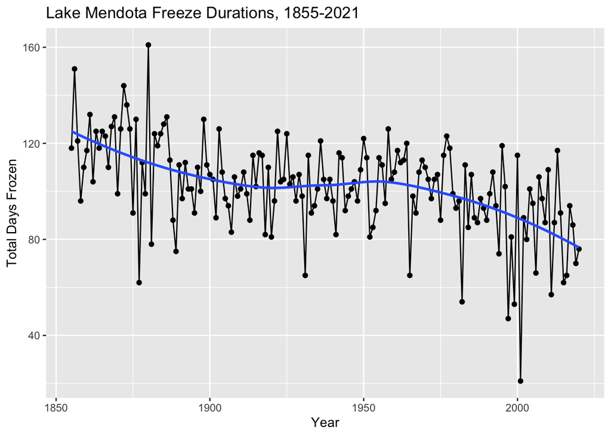

```r
## note setting the aesthetics here in ggplot()
## otherwise, we would need to set in geom_point(), geom_line(), and geom_smooth()
ggplot(mendota, aes(x=year1, y=duration)) +
  geom_point() +
  geom_line() +
  geom_smooth(se=FALSE) +
  xlab("Year") +
  ylab("Total Days Frozen") +
  ggtitle("Lake Mendota Freeze Durations, 1855-2021")
```